# What Makes Me Interact With Advertisements?

*Purpose:*

This report looks at the types of advertisements observed across various platforms and the interactions with them.

Each observation represents a single advertisement I observed online, including information about the platform, advertisement category, advertisement length, and whether the interaction occurred.

The data was collected through observational logging.

## Where Were the Advertisements Seen?

[figure not shown]

A horizontal bar graph displaying observed number of advertisements per platform with Instagram as the most, followed by Facebook, Youtube, Google, and Other

Quick Explanation:

This graph shows that Instagram has the most number of advertisement observations at just over 20, followed by Facebook (Meta), Youtube, Google, and Other.

## What Day of the Week had the Most Advertisements Observed?

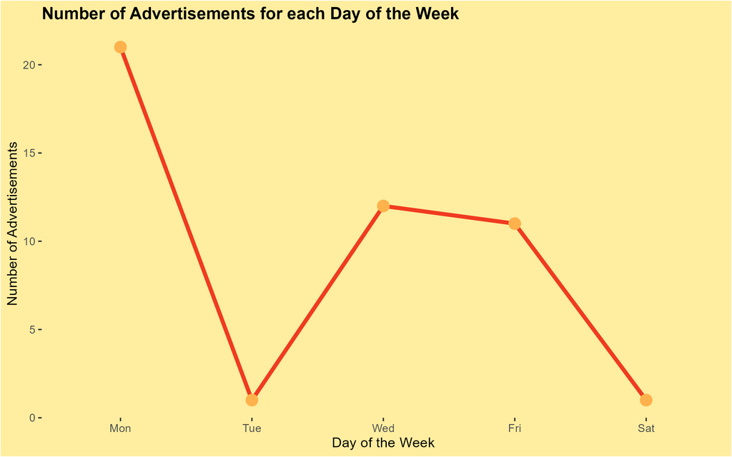

Quick Explanation:

This graph shows that Monday has the most number of advertisements logged, with Wednesday and Friday having about the same, up from Tuesday and Saturday with 1 observation, and Thursday and Sunday having no observations.

## Does Advertisement Length Influence Interaction?

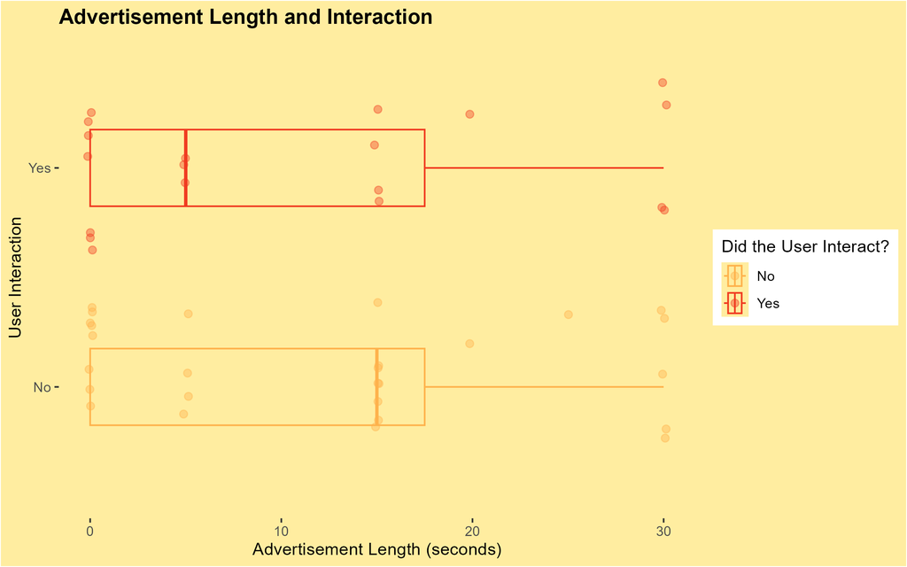

Quick Explanation:

This graph shows that both medians are within the IQR of each other, but Interactions having a lower median then no interactions. Overall, nothing statistically significant.

## What Advertisement Category had the Highest Interaction Rate?

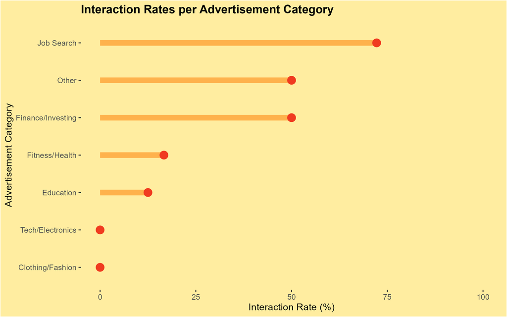

Quick Explanation: